# MODELO FACTORIAL MULTIVARIANTE PARA LA ELABORACIÓN DE UN ÍNDICE MULTIDIMENSIONAL EN LAS COMUNIDADES DE MACROINVERTEBRADOS

## 4.1 IMCM para los años 1995 y 2021:

**Código**

```r
highchart() %>%
    hc_chart(type = "column",
             options3d = list(enabled = TRUE,
                              beta = 15,
                              alpha = 15)) %>%  # Tipo de gráfico: columnas
    hc_xAxis(categories = indices_mcm$RIOS) %>%  # Especificar las categorías en el eje X
    hc_add_series(data = indices_mcm$IMCM,
                  color = "#6096ba") %>%
    hc_xAxis(labels = list(rotation = -45,
                           align = "right"),
             margin = 100) %>%
    hc_title(text = "Índice Multidimensional de las Comunidades de Macroinvertebrados por Estaciones de Monitoreo en los años 1995 y 2021") %>%
    hc_caption(text = "Elaborado por: Marcelo Chávez") %>%
    hc_legend(enabled = FALSE) %>%
    hc_tooltip(formatter = JS("function() {
                             return '<b>RÍO: </b>' + this.x + '<br/>' +
                                    '<b>IMCM: </b>' + this.y.toFixed(2);}")) %>%
    hc_add_theme(hc_theme_google())
```

[interactive chart not shown]

## 4.2 IMCM en el año 1995:

**Código**

```r
highchart() %>%
    hc_chart(type = "column",
             options3d = list(enabled = TRUE,
                              beta = 15,
                              alpha = 15)) %>%  # Tipo de gráfico: columnas
    hc_xAxis(categories = indices_mcm_95$RIOS) %>%  # Especificar las categorías en el eje X
    hc_add_series(data = indices_mcm_95$IMCM,
                  color = "#6096ba") %>%
    hc_xAxis(labels = list(rotation = -45,
                           align = "right"),
             margin = 100) %>%
    hc_title(text = "Índice Multidimensional de las Comunidades de Macroinvertebrados por Estaciones de Monitoreo en el año 1995") %>%
    hc_caption(text = "Elaborado por: Marcelo Chávez") %>%
    hc_legend(enabled = FALSE) %>%
    hc_tooltip(formatter = JS("function() {
                             return '<b>RÍO: </b>' + this.x + '<br/>' +
                                    '<b>IMCM: </b>' + this.y.toFixed(2);}")) %>%
    hc_add_theme(hc_theme_google())
```

[interactive chart not shown]

## 4.3 IMCM en el año 2021:

**Código**

```r
highchart() %>%
    hc_chart(type = "column",
             options3d = list(enabled = TRUE,
                              beta = 15,
                              alpha = 15)) %>%  # Tipo de gráfico: columnas
    hc_xAxis(categories = indices_mcm_21$RIOS) %>%  # Especificar las categorías en el eje X
    hc_add_series(data = indices_mcm_21$IMCM,
                  color = "#6096ba") %>%
    hc_xAxis(labels = list(rotation = -45,
                           align = "right"),
             margin = 100) %>%
    hc_title(text = "Índice Multidimensional de las Comunidades de Macroinvertebrados por Estaciones de Monitoreo en el año 2021") %>%
    hc_caption(text = "Elaborado por: Marcelo Chávez") %>%
    hc_legend(enabled = FALSE) %>%
    hc_tooltip(formatter = JS("function() {
                             return '<b>RÍO: </b>' + this.x + '<br/>' +
                                    '<b>IMCM: </b>' + this.y.toFixed(2);}")) %>%
    hc_add_theme(hc_theme_google())
```

[interactive chart not shown]

# 5 Clústering de las estaciones de monitoreo (Ríos):

Para los clusterización de las estaciones de monitoreo se empleará un método **No Paramétrico** que se encuentra dentro de los métodos de **Aprendizaje No Supervisado**, esto dado porque no se está utilizando una variable en específico que nos permita clasificar para entrenar un modelo factorial.

En el proceso de cluster para las estaciones de monitoreo, se utiliza la misma estructura matricial de los índices físico-químicos y ecológicos. Por consiguiente se utiliza el siguiente proceso algorítmico:

1. Definición del número óptimo de clústers
2. Algoritmo K-Means

## 5.1 Escalamiento de la matriz de datos y elección del número óptimo de clústers:

**Código**

```r
var_scale <- as.data.frame(lapply(indices_fq_ddc, function(x) if(is.numeric(x)) scale(x) else x))

algoritmo <- kmeans(var_scale,
             centers = 4,
             algorithm = "Hartigan-Wong",
             iter.max = 100) #se cambia center por el numero de cluster
```

## 5.2 Método del codo:

**Código**

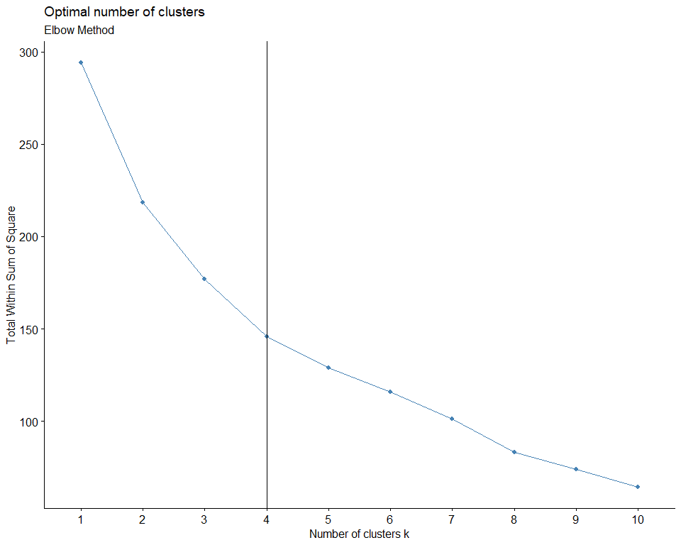

```r
fviz_nbclust(var_scale,
             kmeans,
             method = "wss") +
  labs(subtitle = "Elbow Method") +
  geom_vline(xintercept = 4)
```

## 5.3 Conformación de clústers:

**Código**

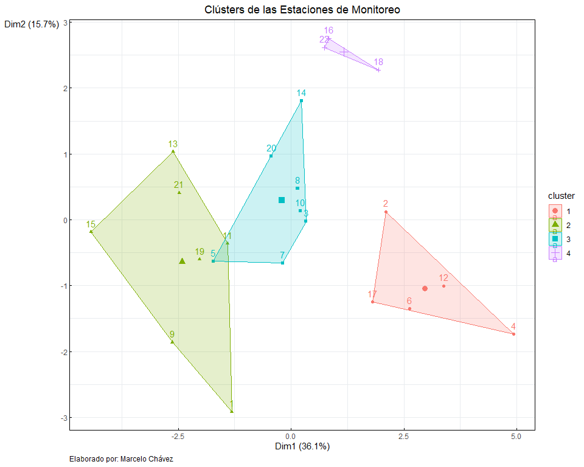

```r
fviz_cluster(algoritmo,
             data = var_scale) +
    theme_minimal() +
    labs(
        title = "Clústers de las Estaciones de Monitoreo",
        caption = "Elaborado por: Marcelo Chávez") +
    theme_minimal() +
    theme(
        axis.text.x = element_text(angle = 0,
                                   vjust = 0.5,
                                   hjust = 0.5),
        axis.title.x = element_text(angle = 0),
        axis.title.y = element_text(angle = 0),
        panel.grid = element_line(color = "#e9ecef", linewidth = 0.5),  # Cambio a linewidth
        panel.border = element_rect(color = "black", fill = NA),
        axis.ticks = element_line(color = "black"),
        axis.line = element_blank(),
        plot.title = element_text(hjust = 0.5),
        plot.caption = element_text(hjust = 0),
        axis.ticks.length = unit(-0.1, "cm"))
```

## 5.4 Tabla final:

**Código**

```r
indices_mcm <- indices_mcm %>%
  mutate(CLUSTER = as.factor(algoritmo$cluster))

DT::datatable(indices_mcm,
              class = 'cell-border stripe',
              # filter = 'top',
              caption = htmltools::tags$caption(
              style = 'caption-side: bottom; text-align: left;',
              'Tabla 3: ', htmltools::em('Indicadores Físico-Químicos y Ecológicos para los años 1995 y 2021 con el cálculo del Índice Multidimensional de las Comunidades de Macroinvertebrados (IMCM) y el número de clúster que corresponde')),
              extensions = c('Buttons','Scroller'),
              options = list(scrollX = TRUE,
                             initComplete = JS(
    "function(settings, json) {",
    "$(this.api().table().header()).css({'background-color': '#003566', 'color': '#fff'});",
    "}"),
    dom = 'Bfrtip',
    buttons = c('excel'),
    deferRender = TRUE,
    scrollY = 500,
    scroller = TRUE))
```

[output not shown]

[output cut: 12 more lines]

## Referencias

Abdi, Hervé. 2010. «Coefficient of Variation». En *Encyclopedia of Research Design*, editado por Neil Salkind. Thousand Oaks, CA: Sage.

Gutiérrez Pulido, Humberto, y Román de la Vara Salazar. 2004. *Análisis y diseño de experimentos*. McGraw-Hill.

Hair, Joseph F, Rolph E Anderson, Ronald L Tatham, y William C Black. 1999. *Análisis Multivariante*. 5.ª ed. Madrid: Pearson-Prentice Hall.

Walpole, Ronald E, Raymond H Myers, Sharon L Myers, y Keying Ye. 2012. *Probability & Statistics for Engineers & Scientists*. 9th ed. Pearson. https://bibliotecavirtualaserena.wordpress.com/wp-content/uploads/2017/05/libro_probabilidad-y-estadistica-para-ingenerc3ada-y-ciencias-ronald-e-walpole-mayers.pdf.

Wang, Beibei, Fengzhu Sun, y Yihui Luan. 2024. «Comparison of the effectiveness of different normalization methods for metagenomic cross-study phenotype prediction under heterogeneity». *Scientific Reports* 14 (1): 7024. https://doi.org/10.1038/s41598-024-57670-2.

A Notebook de **R** by [Marcelo Chávez Reinoso](https://github.com/marcelochavez-ec)

*marcelo_chavez_ec@outlook.com*